# Abalone Report - Simple

Melinda Higgins

2022-09-10

## Make a plot of Age (Y-axis) by Whole Weight (X-axis)

Let’s make a 2 dimensional scatterplot of the abalone `age` by `wholeWeight`. We’ll also overlay a best fit line by `sex.` And we’ll add some better labels and title.

Learn more about `ggplot2` graphics at:

- http://www.cookbook-r.com/Graphs/
- https://r-graphics.org/
- https://ggplot2-book.org/
- and the great examples at https://r-graph-gallery.com/index.html
- including cutomizing legend titles at https://r-graph-gallery.com/239-custom-layout-legend-ggplot2.html

Notice that we can SEE the R code used here.

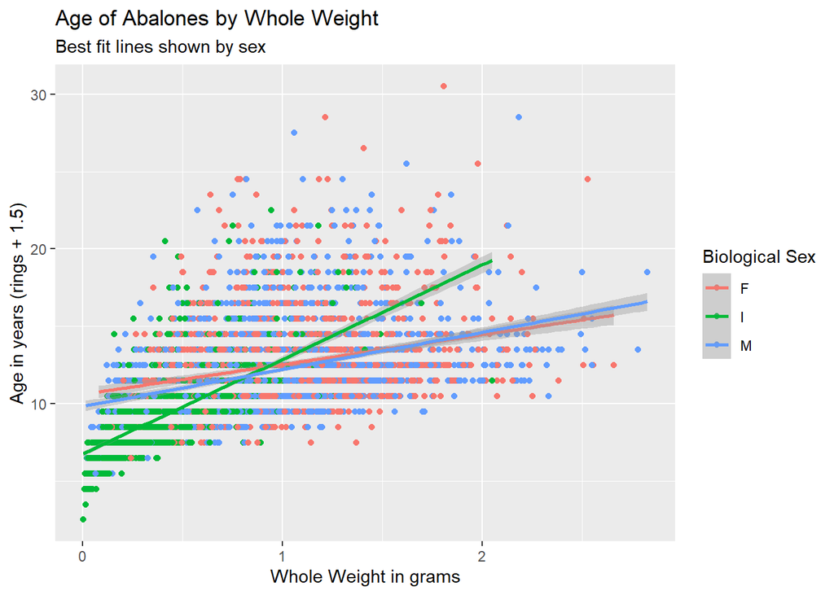

```r
ggplot(abalone, aes(wholeWeight, age, color = sex)) +
  geom_point() +
  geom_smooth(method = lm) +
  xlab("Whole Weight in grams") +
  ylab("Age in years (rings + 1.5)") +
  labs(title = "Age of Abalones by Whole Weight",
       subtitle = "Best fit lines shown by sex") +
  labs(color = "Biological Sex")
```

## Inline r code to insert results inside a sentence

Here is an example of writing a sentence with some results that are automatically inserted. For example, the average age of the 4177 abalones is 11.4336845.

## Making a simple table

Here is a simple table with a caption using the `table()` function and the `knitr::kable()` options for formatting.

```r
# a simple table
abalone %>%
  select(sex) %>%
  table()
```

| F | I | M |
| --- | --- | --- |
| 1307 | 1342 | 1528 |

Now adding a caption

```r
# a simple table
abalone %>%
  select(sex) %>%
  table() %>%
  knitr::kable(caption = "Biological Sex of Abalones - Counts")
```

Biological Sex of Abalones - Counts

| sex | Freq |
| --- | --- |
| F | 1307 |
| I | 1342 |
| M | 1528 |

Next add some custom column headings

```r
# a simple table
abalone %>%
  select(sex) %>%
  table() %>%
  knitr::kable(caption = "Biological Sex of Abalones - Counts",
               col.names = c("Biological Sex", "Frequency"))
```

Biological Sex of Abalones - Counts

| Biological Sex | Frequency |
| --- | --- |
| F | 1307 |
| I | 1342 |
| M | 1528 |

## Very brief intro to `gtsummary` package

Another “tidyverse” compatible R package for working with tables is the `gtsummary` package.

Learn more at:

- https://www.danieldsjoberg.com/gtsummary/index.html
- specifically review the vignette for the `tbl_summary()` function https://www.danieldsjoberg.com/gtsummary/articles/tbl_summary.html

The code below will produce a table with summary statistics based on the variable type:

- `sex` is categorical character variable so you get frequencies and percents of the total;
- `age` is continuous numeric variable so you get the median and IQR (interquartile range) by default.

```r
library(gtsummary)
abalone %>%
  select(sex, age) %>%
  tbl_summary()
```

| **Characteristic** | **N = 4,177**<sup>1</sup> |
| --- | --- |
| sex |  |
| F | 1,307 (31%) |
| I | 1,342 (32%) |
| M | 1,528 (37%) |
| age | 10.5 (9.5, 12.5) |

<sup>1</sup> n (%); Median (IQR)

Suppose we instead want to get the mean and standard deviation for `age`. Inside the `tbl_summary()` function we can use the `statistic = list(...)` option.

```r
abalone %>%
  select(sex, age) %>%
  tbl_summary(
    statistic = list(all_continuous() ~ "{mean} ({sd})")
    )
```

| **Characteristic** | **N = 4,177**<sup>1</sup> |
| --- | --- |
| sex |  |
| F | 1,307 (31%) |
| I | 1,342 (32%) |
| M | 1,528 (37%) |
| age | 11.4 (3.2) |

<sup>1</sup> n (%); Mean (SD)

We could take this a step further and get statistics by a grouping variable. For example, let’s get the 3 dimensional measurements by `sex`. Inside the `tbl_summary()` function we can use the `by = group` option.

```r
abalone %>%
  select(height, diameter, length, sex) %>%
  tbl_summary(
    by = sex,
    statistic = list(all_continuous() ~ "{mean} ({sd})")
    )
```

| **Characteristic** | **F**, N = 1,307<sup>1</sup> | **I**, N = 1,342<sup>1</sup> | **M**, N = 1,528<sup>1</sup> |
| --- | --- | --- | --- |
| height | 0.16 (0.04) | 0.11 (0.03) | 0.15 (0.03) |
| diameter | 0.45 (0.07) | 0.33 (0.09) | 0.44 (0.08) |
| length | 0.58 (0.09) | 0.43 (0.11) | 0.56 (0.10) |

<sup>1</sup> Mean (SD)